# The k - Armed Bandit Problem

###### By Rohit Pardasani

Consider the following learning problem. You are faced repeatedly with a choice among k different options, or actions.  
After each choice you receive a numerical reward chosen from a stationary probability distribution that depends on the action you selected.  
Your objective is to maximize the expected total reward over some time period, for example, over 1000 action selections, or time steps.  
$t$ = time step  
$A_t$ = action at $t$  
$R_t$ = reward at $t$ for corresponding to $A_t$  
$a$ = an arbitrary action  
$q_*(a)$ = expected reward given $a$ is selected  
$q_{*}(a)$ is **value** of action. But it's not known. If we would have known it, this problem is trivial.

### Example

Let's say there are 5 possible actions with reward distribution shown as below i.e. $a=1,2,3,4,5$

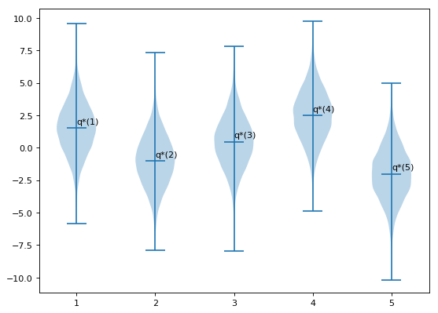

```python
import numpy as np
import matplotlib.pyplot as plt
Ma = 1.5
Mb = -1.0
Mc = 0.5
Md = 2.5
Me = -2.0
np.random.seed(1)
Da = np.random.normal(loc=Ma, scale=2.0, size=10000)
Db = np.random.normal(loc=Mb, scale=2.0, size=10000)
Dc = np.random.normal(loc=Mc, scale=2.0, size=10000)
Dd = np.random.normal(loc=Md, scale=2.0, size=10000)
De = np.random.normal(loc=Me, scale=2.0, size=10000)
plt.figure(figsize=(8, 6), dpi=80)
plt.violinplot([Da,Db,Dc,Dd,De],showmeans=True)
plt.text(1,Ma+0.3,'q*(1)')
plt.text(2,Mb+0.3,'q*(2)')
plt.text(3,Mc+0.3,'q*(3)')
plt.text(4,Md+0.3,'q*(4)')
plt.text(5,Me+0.3,'q*(5)')
plt.show()
```

$Q_t(a)$ is estimated value of action $a$ at time step $t$. We would like $Q_t(a)$ to be close to $q_*(a)$  
The methods for estimating the values of actions and for using the estimates to make action selection decisions are collectively call action-value methods. One of the method is below. This is called **sample average method**.

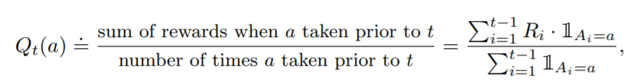

where $\mathbb{1}_{predicate}$ denotes the random variable that is 1 if predicate is true and 0 if it is not. If the denominator is zero, then we instead define $Q_t(a)$ as some default value, such as 0. As the denominator goes to infinity, by the law of large numbers, $Q_t(a)$ converges to $q_*(a)$.

### Exploitation - Exploration Tradeoff

#### Exploitation

Selecting a greedy action.  
The greedy action is one which has highest estimated value based on current knowledge of value of actions.

#### Exploring

Select one of the nongreedy actions  
This enables you to improve your estimate of the nongreedy action’s value.  
Exploitation is the right thing to do to maximize the expected reward on the one step, but exploration may produce the greater total reward in the long run.  
Because it is not possible both to explore and to exploit with any single action selection, one often refers to the “conflict” between exploration and exploitation.

### Greedy Action Selection

Greedy action selection always exploits current knowledge to maximize immediate reward; it spends no time at all sampling apparently inferior actions to see if they might really be better.

### $\epsilon$ - Greedy

A simple alternative is to behave greedily most of the time, but every once in a while, say with small probability $\epsilon$, instead select randomly from among all the actions with equal probability, independently of the action-value estimates.  
We call methods using this near-greedy action selection rule $\epsilon$ greedy methods.  
An advantage of these methods is that, in the limit as the number ofsteps increases, every action will be sampled an infinite number of times, thus ensuring that all the $Q_t(a)$ converge to $q_*(a)$.  
One of the problem with sample average method is that it we need to keep record of every reward. Let's say for $R_i$ is the reward for a particular action $a$ when it was called $i^{th}$ time and $Q_j$ is estimate of the reward when deciding to take this action (action $a$) the $j^{th}$ time.  
Instead of storing all rewards till now, we just store the last estimate (as shown below)

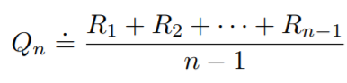

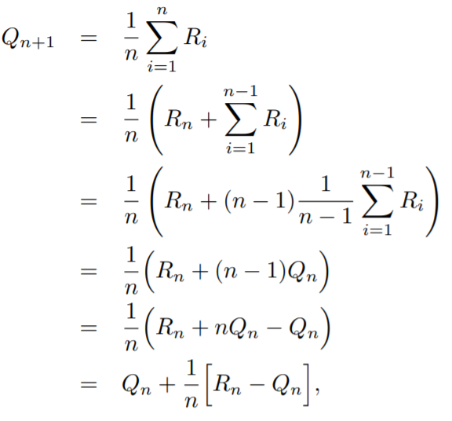

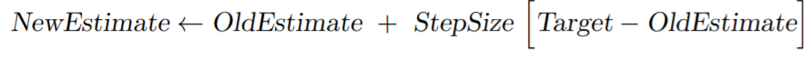

```python
# Set an epsilon
# Store counts of each action in an array of length 5. Initialized to zero
# Store estimated reward of each action in array of length 5. Initialized to zero.
# Store reward at each step, 1000 steps, so array of length 1000
# Need to run this 1000 step iterations 100 times to get an average graph
import numpy as np
import random

def choseAction(Q,e):
    rd = np.random.uniform(0,1)
    if(rd<e):
        return (random.randint(0,4))
    else:
        return np.argmax(Q) # Pick a greedy action

def getReward(c,D):
    return (np.random.choice(D[c,:]))

def updateMatrices(i,c,r,Q,C,R,Ac): #We get reward of r by chosing c in i_th step
    Q[c] = (C[c]*Q[c] + r)/(C[c]+1)
    C[c]+=1
    R[i]+=r
    Ac[c,i] += 1
    return Q,C,R,Ac


D = np.zeros((5,10000))
D[0,:] = Da
D[1,:] = Db
D[2,:] = Dc
D[3,:] = Dd
D[4,:] = De
N = 1000


np.random.seed(1)
random.seed(1)
# e=0, Greedy
e = 0
Ac = np.zeros((5,1000)) # Number of times an action get's picked up
R = np.zeros(1000) #1000 step rewards sum
for n in range(N):
    Q = np.zeros(5) #Qs
    C = np.zeros(5) #Counts
    for i in range(1000):
        c = choseAction(Q,e)
        r = getReward(c,D)
        Q,C,R,Ac = updateMatrices(i,c,r,Q,C,R,Ac)

R_0 = R/N
OptFrac_0 = Ac[3,:]/N # c=3 is optimal action,what is the fraction of times it gets picked
print('---- e = %.3f completed------'%e)

# e=0.01, Epsilon Greedy
e = 0.01
Ac = np.zeros((5,1000)) # Number of times an action get's picked up
R = np.zeros(1000) #1000 step rewards sum
for n in range(N):
    Q = np.zeros(5) #Qs
    C = np.zeros(5) #Counts
    for i in range(1000):
        c = choseAction(Q,e)
        r = getReward(c,D)
        Q,C,R,Ac = updateMatrices(i,c,r,Q,C,R,Ac)

R_1 = R/N
OptFrac_1 = Ac[3,:]/N # c=3 is optimal action,what is the fraction of times it gets picked
print('---- e = %.3f completed------'%e)

# e=0.1, Epsilon Greedy
e = 0.1
Ac = np.zeros((5,1000)) # Number of times an action get's picked up
R = np.zeros(1000) #1000 step rewards sum
for n in range(N):
    Q = np.zeros(5) #Qs
    C = np.zeros(5) #Counts
    for i in range(1000):
        c = choseAction(Q,e)
        r = getReward(c,D)
        Q,C,R,Ac = updateMatrices(i,c,r,Q,C,R,Ac)

R_2 = R/N
OptFrac_2 = Ac[3,:]/N # c=3 is optimal action,what is the fraction of times it gets picked
print('---- e = %.3f completed------'%e)

# e=0.2, Epsilon Greedy
e = 0.2
Ac = np.zeros((5,1000)) # Number of times an action get's picked up
R = np.zeros(1000) #1000 step rewards sum
for n in range(N):
    Q = np.zeros(5) #Qs
    C = np.zeros(5) #Counts
    for i in range(1000):
        c = choseAction(Q,e)
        r = getReward(c,D)
        Q,C,R,Ac = updateMatrices(i,c,r,Q,C,R,Ac)

R_3 = R/N
OptFrac_3 = Ac[3,:]/N # c=3 is optimal action,what is the fraction of times it gets picked
print('---- e = %.3f completed------'%e)
```

```
---- e = 0.000 completed------
---- e = 0.010 completed------
---- e = 0.100 completed------
---- e = 0.200 completed------
```

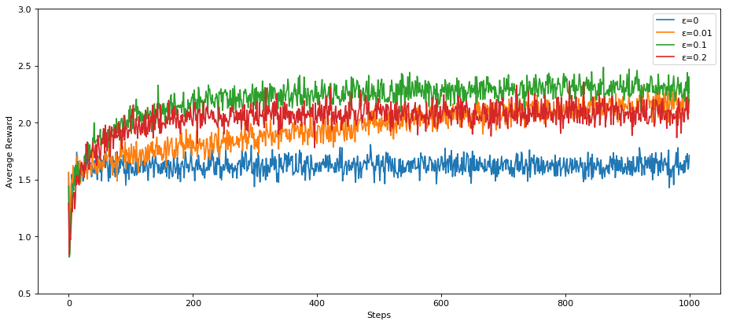

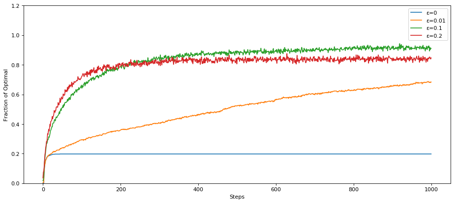

```python
plt.figure(figsize=(14, 6), dpi=80)
plt.ylim(0.5,3)
plt.ylabel('Average Reward')
plt.xlabel('Steps')
plt.plot(R_0,label='\u03B5=0')
plt.plot(R_1,label='\u03B5=0.01')
plt.plot(R_2,label='\u03B5=0.1')
plt.plot(R_3,label='\u03B5=0.2')
plt.legend()
plt.show()

plt.figure(figsize=(14, 6), dpi=80)
plt.ylim(0.0,1.2)
plt.ylabel('Fraction of Optimal')
plt.xlabel('Steps')
plt.plot(OptFrac_0,label='\u03B5=0')
plt.plot(OptFrac_1,label='\u03B5=0.01')
plt.plot(OptFrac_2,label='\u03B5=0.1')
plt.plot(OptFrac_3,label='\u03B5=0.2')
plt.legend()
plt.show()
```

### Tracking a Nonstationary Problem

The averaging methods discussed so far are appropriate for stationary bandit problems, that is, for bandit problems in which the reward probabilities do not change over time.  
As noted earlier, we often encounter reinforcement learning problems that are effectively nonstationary. In such cases it makes sense to give more weight to recent rewards than to long-past rewards. One of the most popular ways of doing this is to use a constant step-size parameter. For example

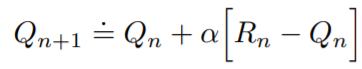

$\alpha \in (0,1] $

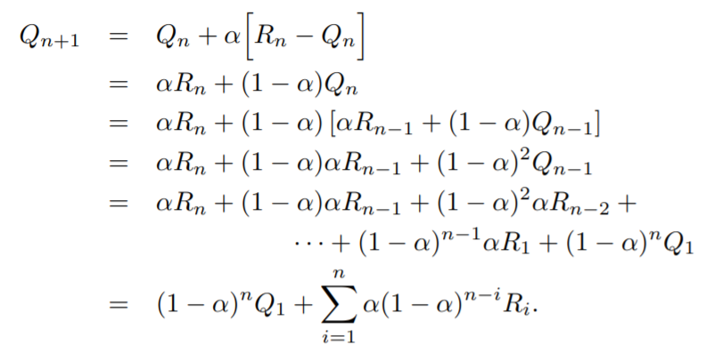

this is sometimes called an exponential recency-weighted average. We know that $\alpha=1/n$ leads to sample average method.

#### Condition on $\alpha$

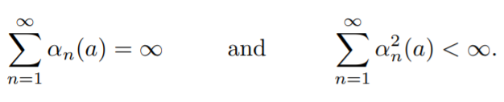

The first condition is required to guarantee that the steps are large enough to eventually overcome any initial conditions or random fluctuations.  
The second condition guarantees that eventually the steps become small enough to assure convergence.

### Optimistic Initial Values

All the methods we have discussed so far are dependent to some extent on the initial action-value estimates (or biased by their initial estimates)  
For the sample-average methods, the bias disappears once all actions have been selected at least once, but for methods with constant, the bias is permanent, though decreasing over time  
To encourage exploration at initial stages we can set optimistic initial value  
But obviously this approach is valid only for stationary problems  
For example instead of initializing values of Qs to 0 initially we can intialize them 5 in greedy  
Below graph compares the effect

```python
np.random.seed(1)
random.seed(1)
# e=0, Greedy with Q intialized to +5
e = 0
Ac = np.zeros((5,1000)) # Number of times an action get's picked up
R = np.zeros(1000) #1000 step rewards sum
for n in range(N):
    Q = 5*np.ones(5) #Qs
    C = 1*np.ones(5) #Counts
    for i in range(1000):
        c = choseAction(Q,e)
        r = getReward(c,D)
        Q,C,R,Ac = updateMatrices(i,c,r,Q,C,R,Ac)

OptFrac_a = Ac[3,:]/N # c=3 is optimal action,what is the fraction of times it gets picked

# e=0.1, Epsilon Greedy with Q initialized to 0
e = 0.1
Ac = np.zeros((5,1000)) # Number of times an action get's picked up
R = np.zeros(1000) #1000 step rewards sum
for n in range(N):
    Q = np.zeros(5) #Qs
    C = np.zeros(5) #Counts
    for i in range(1000):
        c = choseAction(Q,e)
        r = getReward(c,D)
        Q,C,R,Ac = updateMatrices(i,c,r,Q,C,R,Ac)

OptFrac_b = Ac[3,:]/N # c=3 is optimal action,what is the fraction of times it gets picked
```

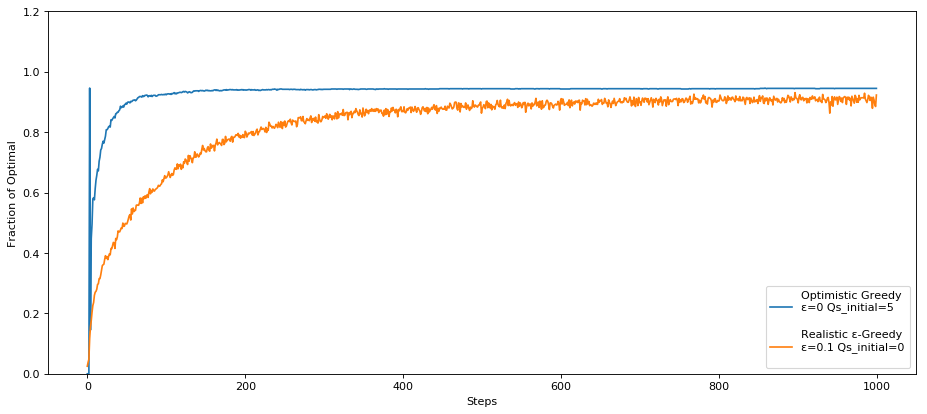

```python
plt.figure(figsize=(14, 6), dpi=80)
plt.ylim(0.0,1.2)
plt.ylabel('Fraction of Optimal')
plt.xlabel('Steps')
plt.plot(OptFrac_a,label='Optimistic Greedy \n\u03B5=0 Qs_initial=5\n')
plt.plot(OptFrac_b,label='Realistic \u03B5-Greedy \n\u03B5=0.1 Qs_initial=0\n')
plt.legend()
plt.show()
```

### Upper-Confidence-Bound Action Selection

It would be better to select among the non-greedy actions according to their potential for actually being optimal, taking into account both how close their estimates are to being maximal and the uncertainties in those estimates.  
One effective way of doing this is to select actions according to:

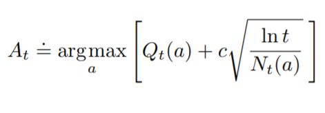

where $ln$ $t$ denotes the natural logarithm of time step  
$N_t(a)$ denotes the number of times that action a has been selected prior to time t  
and the number c > 0 controls the degree of exploration  
The idea of this upper confidence bound (UCB) action selection is that the square-root term is a measure of the uncertainty or variance in the estimate of a’s value.  
UCB often performs well, as shown here, but is more dicult than $\epsilon$-greedy to extend beyond bandits to the more general reinforcement learning settings

```python
def choseActionUCB(Q,C,i):
    Q_ucb = np.zeros(len(Q))
    for k in range(len(Q)):
        Q_ucb[k] = Q[k] + 2*np.sqrt(np.log(i+1)/(C[k]+1)) # Used +1 to avoid zero in numerator and denominator
    return np.argmax(Q_ucb)

np.random.seed(1)
random.seed(1)
# Choose action using UCB
Ac = np.zeros((5,1000)) # Number of times an action get's picked up
R = np.zeros(1000) #1000 step rewards sum
for n in range(N):
    Q = np.zeros(5) #Qs
    C = np.zeros(5) #Count
    for i in range(1000):
        c = choseActionUCB(Q,C,i)
        r = getReward(c,D)
        Q,C,R,Ac = updateMatrices(i,c,r,Q,C,R,Ac)

OptFrac_a = Ac[3,:]/N # c=3 is optimal action,what is the fraction of times it gets picked

# e=0.1, Epsilon Greedy with Q initialized to 0
e = 0.1
Ac = np.zeros((5,1000)) # Number of times an action get's picked up
R = np.zeros(1000) #1000 step rewards sum
for n in range(N):
    Q = np.zeros(5) #Qs
    C = np.zeros(5) #Counts
    for i in range(1000):
        c = choseAction(Q,e)
        r = getReward(c,D)
        Q,C,R,Ac = updateMatrices(i,c,r,Q,C,R,Ac)

OptFrac_b = Ac[3,:]/N # c=3 is optimal action,what is the fraction of times it gets picked
```

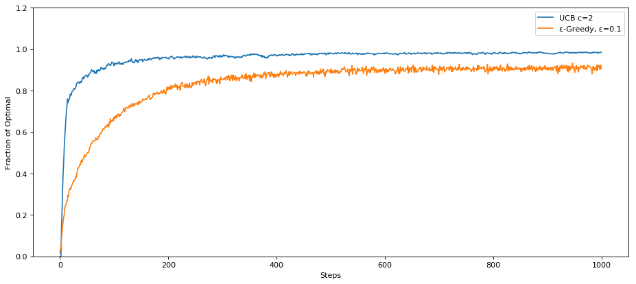

```python
plt.figure(figsize=(14, 6), dpi=80)
plt.ylim(0.0,1.2)
plt.ylabel('Fraction of Optimal')
plt.xlabel('Steps')
plt.plot(OptFrac_a,label='UCB c=2')
plt.plot(OptFrac_b,label='\u03B5-Greedy, \u03B5=0.1')
plt.legend()
plt.show()
```

### References

https://mitpress.mit.edu/books/reinforcement-learning  
https://www.coursera.org/specializations/reinforcement-learning